```python
import pandas as pd
```

# 解决matplotlib中文乱码

```python
# 解决matplotlib中文乱码
matplotlib.rcParams['font.sans-serif'] = ['SimHei']
matplotlib.rcParams['font.serif'] = ['SimHei']
matplotlib.rcParams['axes.unicode_minus'] = False
```

# matlabplot

matplotlibt.pyplot才能使用plt

```python
import matplotlib
import matplotlib.pyplot as plt
```

## 饼图

https://pandas.pydata.org/pandas-docs/stable/reference/api/pandas.DataFrame.plot.pie.html

创建图：fig = plt.figure()

**也可以直接plt.pie()**

在y中填各参数比例

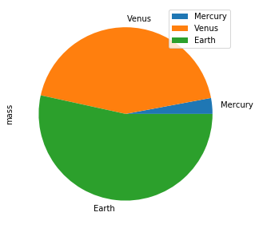

```python
df = pd.DataFrame({'mass': [0.330, 4.87 , 5.97],
                   'radius': [2439.7, 6051.8, 6378.1]},
                  index=['Mercury', 'Venus', 'Earth'])
plot = df.plot.pie(y='mass', figsize=(5, 5))
```

[output not shown]

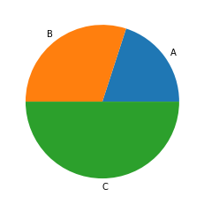

```python
'''
或使用 y = [0.2,0.3,0.5], labels = ["A","B","C"]
'''
y = [0.2,0.3,0.5]
labels = ["A","B","C"]
plt.pie(y, labels = labels)
```

[output not shown]

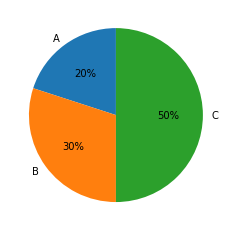

```python
plt.pie(y, labels=labels, autopct='%1.0f%%', startangle=90) # startangle是图旋转角度
```

### 调整字体大小

[figure not shown]

```python
plt.xticks(size=16, rotation=45) # x轴字体大小调整
plt.yticks(size=16) # y轴字体大小调整
```

## 柱状图

df.plot(kind = "bar") #用pandas

ax[0].bar(x,y) # 用matplotlib

plt.figure(figsize=(8,8),dpi=80)

plt.style.use('ggplot')

plt.title("顾客的平均评分")

plt.ylim(ymin=0,ymax=100) # y轴坐标，最小值0.最大值设为100

plt.bar(x, y, width=0.2, color='#6699CC')

## 直方图

hist, bin_edges = np.histogram(price_series, bins=80) #生成直方图函数

## 同时画多个图的Tutorial

1. https://matplotlib.org/tutorials/introductory/pyplot.html
2. https://matplotlib.org/devdocs/gallery/subplots_axes_and_figures/subplots_demo.html

### 使用ax后如何修改xtick

- https://www.geeksforgeeks.org/matplotlib-axes-axes-set_xticks-in-python/

```python
axes.set_xticks(ticks, minor=False) # set ticks
```

```python
'''
Warning

This method should only be used after fixing the tick positions using Axes.set_xticks. Otherwise, the labels may end up in unexpected positions.
'''
axes.set_xticklabels(labels, fontdict=None, minor=False)
```

## 图例修改

### 修改xlable或ylabel

plt.xlabel("name")

### 改图像标签

document 在：https://matplotlib.org/api/pyplot_api.html#matplotlib.pyplot.legend

- plt.legend("内容") #修改内容
- plot.legend(loc=2, prop={'size': 6})

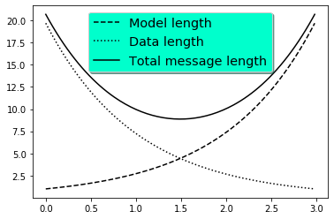

```python
"""
===============================
Legend using pre-defined labels
===============================

Notice how the legend labels are defined with the plots!
"""


import numpy as np
import matplotlib.pyplot as plt

# Make some fake data.
a = b = np.arange(0, 3, .02)
c = np.exp(a)
d = c[::-1]

# Create plots with pre-defined labels.
fig, ax = plt.subplots()
ax.plot(a, c, 'k--', label='Model length')
ax.plot(a, d, 'k:', label='Data length')
ax.plot(a, c + d, 'k', label='Total message length')

legend = ax.legend(loc='upper center', shadow=True, fontsize='x-large')

# Put a nicer background color on the legend.
legend.get_frame().set_facecolor('#00FFCC')

plt.show()
```

### 图例显示不全

https://blog.csdn.net/weixin_33913332/article/details/89688219?utm_medium=distribute.pc_relevant.none-task-blog-BlogCommendFromMachineLearnPai2-4.nonecase&depth_1-utm_source=distribute.pc_relevant.none-task-blog-BlogCommendFromMachineLearnPai2-4.nonecase

# pandas使用技巧

## 去除重复项

df.drop_duplicates()

https://pandas.pydata.org/pandas-docs/stable/reference/api/pandas.DataFrame.drop_duplicates.html

## 获取非null部分

```python
df.notnull()
```

|  | mass | radius |
| --- | --- | --- |
| Mercury | True | True |
| Venus | True | True |
| Earth | True | True |

## 柱状图

df3.plot(kind = "bar")

## 分箱

简书：https://www.jianshu.com/p/0805f185ecdf

pandas: https://pandas.pydata.org/pandas-docs/stable/reference/api/pandas.cut.html?highlight=cut#pandas.cut

pandas.cut(x, bins, right=True, labels=None, retbins=False, precision=3, include_lowest=False, duplicates='raise', ordered=True)[source]

```python
import numpy as np
import pandas as pd
from pandas import Series, DataFrame

score_list = np.random.randint(30, 100, size=20)
print(score_list)
```

```
[37 75 57 48 34 88 76 58 59 45 68 79 72 69 91 75 83 85 71 48]
```

```python
# 然后我们再设置分箱:
bins=[0,59,70,80,100]
```

```python
#这就表示数据有0-59，59-70，70-80，80-100这几个等级。
#下面把分箱和分数利用cut方法结合到一起。

score_cat = pd.cut(score_list, bins)
print(pd.value_counts(score_cat))
```

```
(0, 59]      8
(70, 80]     6
(80, 100]    4
(59, 70]     2
dtype: int64
```

```python
rank = ["A","B","C","D"]
score_cat2 = pd.cut(score_list, bins, labels = rank)
score_cat2
```

```
[A, C, A, A, A, ..., C, D, D, C, A]
Length: 20
Categories (4, object): [A < B < C < D]
```

## 修改时间格式

df_payed_order['时间'] = df_payed_order['订单创建时间'].astype('datetime64[D]')

### pandas.to_datetime() 只保留【年-月-日】

Outline

pandas.to_datetime() 生成的日期会默认带有 【2019-07-03 00:00:00】的分钟精度；

但有时并不需要这些分钟精度；

去掉分钟精度

可以通过pandas中的 .dt.date 去掉分钟。

df['just_date'] = df['dates'].dt.date

（padnas 版本 要大于等于 0.15.0）

转载于:https://www.cnblogs.com/bigtreei/p/11126805.html

### 使用strftime修改为指定格式

user_df['date_account_created'].apply(lambda x: x.strftime('%y-%m'))

### 经常报错

D:\anaconda3\lib\site-packages\ipykernel_launcher.py:1: SettingWithCopyWarning: A value is trying to be set on a copy of a slice from a DataFrame. Try using .loc[row_indexer,col_indexer] = value instead

See the caveats in the documentation: https://pandas.pydata.org/pandas-docs/stable/user_guide/indexing.html#returning-a-view-versus-a-copy """Entry point for launching an IPython kernel.

**使用iloc配合[:，]**

```python
# user_df['date_account_created'] = pd.to_datetime(user_df.loc[:, 'date_account_created'])
```